# Trabajo Práctico PCA

Autores/as

Afiliación

Miguel Garrone

Universidad Austral

Lucía Tamplin

Milagros Terán

Martín Ceriotti

## **Introducción**

Trabajo práctico grupal para la materia “Introducción a Data Mining”: Análisis de Componentes Principales (PCA)

## **Descripción de la base de datos**

Los datos del archivo “quinoa.txt” corresponden a 24 accesiones de quinoa nativa del Noroeste Argentino caracterizadas a través de 10 variables cuantitativas y 8 variables cualitativas.

### Variables cuantitativas

1. **DIAMTAL**: Diámetro del tallo (mm)
2. **ALTPL**: Altura de la planta (cm)
3. **LONGHO**: Longitud de la hoja (mm)
4. **ANCHOHO**: Ancho de la hoja (mm)
5. **LONGPEC**: Longitud del peciolo (mm)
6. **LONGPAN**: Longitud de la panoja (cm)
7. **LONGGLO**: Longitud del glomérulo (mm)
8. **DSBF**: Días desde la siembra hasta el botón floral (días)
9. **DSFL**: Días desde la siembra hasta la floración (días)
10. **DSMF**: Días desde la siembra hasta la madurez fisiológica (días)

### Variables cualitativas

1. **AX**: Presencia de axilas (Si – No)
2. **CEstrias**: Color de las estrías (Amarillas – Rojas – Púrpuras – No (no tiene estrías))
3. **CTallo**: Color del tallo (Rojo – Púrpura – Verde)
4. **PoRAMA**: Presencia de ramas (Si – No)
5. **CFA**: Color de la panoja a fin de antesis (Blanca – Púrpura – Gris)
6. **Cco**: Color de la panoja a la cosecha (Amarilla – Blanca – Púrpura – Marrón)
7. **TP**: Tipo de panoja (Diferenciada y terminal – No diferenciada)
8. **FP**: Forma de la panoja (Glomerulada – Amarantiforme)

### Zona

Se decidió agregar una variable llamada “zona” a la base de datos, para determinar en qué zona se desarrolla cada una de las plantas. Los datos fueron obtenidos de la columna “poblaciones”.

- Altiplano (AL)
- Valles de Altura (VA)
- Valles Húmedos (VH)
- Valles secos (VS)

## **Análisis Descriptivo**

### Tabla descriptiva sobre las variables numéricas

|  | DIAMTAL | ALTPL | LONGHO | ANCHOHO | LONGPEC | LONGPAN | LONGGLO | DSBF | DSFL | DSMF |
| --- | --- | --- | --- | --- | --- | --- | --- | --- | --- | --- |
| nbr.val | 24.00 | 24.00 | 24.00 | 24.00 | 24.00 | 24.00 | 24.00 | 24.00 | 24.00 | 24.00 |
| nbr.null | 0.00 | 0.00 | 0.00 | 0.00 | 0.00 | 0.00 | 0.00 | 0.00 | 0.00 | 0.00 |
| nbr.na | 0.00 | 0.00 | 0.00 | 0.00 | 0.00 | 0.00 | 0.00 | 0.00 | 0.00 | 0.00 |
| min | 2.80 | 23.20 | 33.30 | 26.39 | 16.45 | 50.74 | 5.12 | 18.00 | 33.00 | 88.00 |
| max | 8.45 | 173.10 | 94.41 | 73.25 | 56.31 | 560.00 | 11.89 | 71.00 | 95.00 | 217.00 |
| range | 5.65 | 149.90 | 61.11 | 46.86 | 39.87 | 509.26 | 6.77 | 53.00 | 62.00 | 129.00 |
| sum | 137.49 | 2480.93 | 1513.04 | 1249.71 | 856.63 | 6637.15 | 217.65 | 1000.00 | 1527.00 | 3716.00 |
| median | 6.15 | 103.50 | 65.59 | 54.38 | 35.49 | 306.50 | 9.39 | 39.00 | 68.00 | 162.50 |
| mean | 5.73 | 103.37 | 63.04 | 52.07 | 35.69 | 276.55 | 9.07 | 41.67 | 63.62 | 154.83 |
| SE.mean | 0.35 | 10.72 | 3.30 | 3.00 | 2.18 | 25.50 | 0.46 | 3.49 | 3.78 | 6.12 |
| CI.mean.0.95 | 0.72 | 22.17 | 6.83 | 6.21 | 4.50 | 52.75 | 0.94 | 7.21 | 7.82 | 12.66 |
| var | 2.87 | 2755.97 | 261.75 | 216.27 | 113.54 | 15604.14 | 5.00 | 291.62 | 342.77 | 899.19 |
| std.dev | 1.69 | 52.50 | 16.18 | 14.71 | 10.66 | 124.92 | 2.24 | 17.08 | 18.51 | 29.99 |
| coef.var | 0.30 | 0.51 | 0.26 | 0.28 | 0.30 | 0.45 | 0.25 | 0.41 | 0.29 | 0.19 |

### Correlación entre variables, distribuciones y gráficos de dispersión

En el gráfico que se presenta a continuación, se puede ver la distribución de cada una de las variables y la correlación que hay entre ellas.

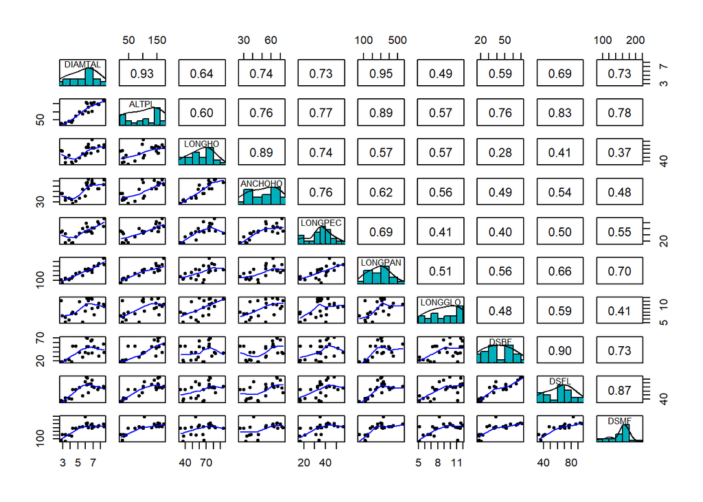

En el gráfico se pueden ver correlaciones altas entre algunas variables y distribuciones poco campanulares.

### Boxplots comparativos entre las variables del conjunto de datos

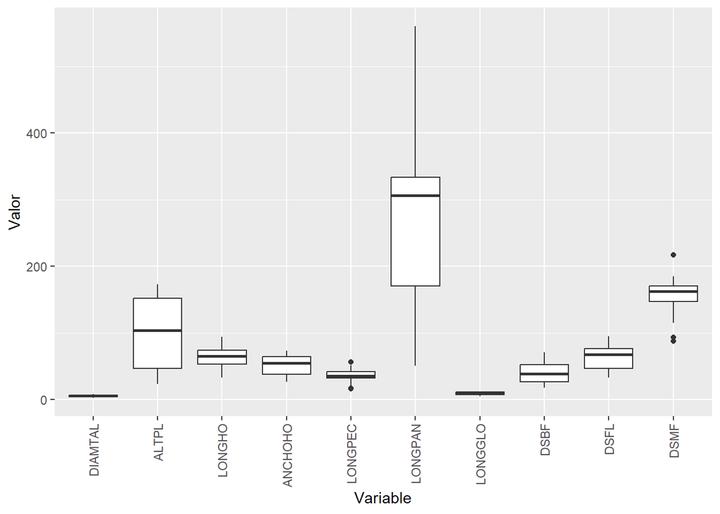

En el gráfico se pueden observar distribuciones muy distintas entre las variables. Además, es posible identificar que están en escalas de medida distintas.

## **Análisis de Componentes Principales (PCA)**

### Proporción de varianza explicada por cada Componente Principal

Proporción de la varianza explicada por cada Componente Principal

|  | PC1 | PC2 | PC3 | PC4 | PC5 | PC6 | PC7 | PC8 | PC9 | PC10 |
| --- | --- | --- | --- | --- | --- | --- | --- | --- | --- | --- |
| Standard deviation | 2.609 | 1.150 | 0.863 | 0.665 | 0.521 | 0.474 | 0.308 | 0.227 | 0.159 | 0.120 |
| Proportion of Variance | 0.681 | 0.132 | 0.074 | 0.044 | 0.027 | 0.022 | 0.010 | 0.005 | 0.003 | 0.001 |
| Cumulative Proportion | 0.681 | 0.813 | 0.888 | 0.932 | 0.959 | 0.981 | 0.991 | 0.996 | 0.999 | 1.000 |

Se pueden observar dos autovalores mayores a 1. Además, se observa que las dos primeras componentes principales explican el 81,30% de la variabilidad total de los datos.

A continuación, se puede observar la misma información obtenida en la tabla anterior, pero de manera gráfica:

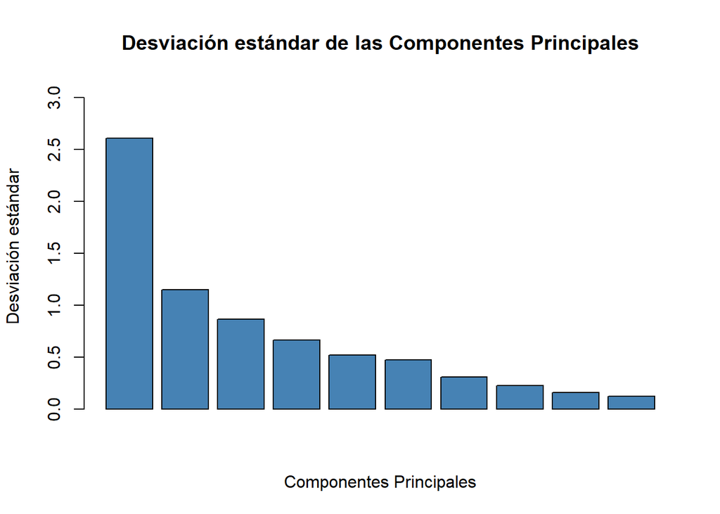

### Matriz de Cargas

|  | PC1 | PC2 | PC3 | PC4 | PC5 | PC6 | PC7 | PC8 | PC9 | PC10 |
| --- | --- | --- | --- | --- | --- | --- | --- | --- | --- | --- |
| DIAMTAL | 0.3532707 | 0.0446199 | -0.3083325 | 0.2927034 | -0.2354113 | -0.1816724 | 0.1231521 | 0.0573555 | 0.7635378 | 0.0509435 |
| ALTPL | 0.3705121 | -0.0662559 | -0.1290653 | 0.0627101 | -0.2164529 | 0.2234864 | 0.2112226 | 0.4115485 | -0.2775036 | -0.6707810 |
| LONGHO | 0.2796666 | 0.5237104 | 0.1699598 | -0.1907599 | 0.0708425 | -0.3920348 | -0.5587679 | -0.0623891 | 0.0269288 | -0.3266333 |
| ANCHOHO | 0.3168600 | 0.3684130 | 0.1292415 | -0.3625181 | -0.3182096 | -0.1916510 | 0.5364573 | -0.0218575 | -0.2302147 | 0.3694569 |
| LONGPEC | 0.3063233 | 0.3126802 | -0.2706768 | -0.2332349 | 0.4361524 | 0.6694692 | -0.0480479 | -0.0572888 | 0.1157301 | 0.1527439 |
| LONGPAN | 0.3378360 | 0.0024264 | -0.3036510 | 0.5417144 | -0.1491091 | -0.0187294 | -0.2938796 | -0.2215277 | -0.4940256 | 0.3132366 |
| LONGGLO | 0.2544180 | 0.0662161 | 0.7585997 | 0.4793186 | 0.2145607 | 0.1791117 | 0.1785646 | -0.0879904 | 0.0883217 | -0.0110189 |
| DSBF | 0.2892518 | -0.4519568 | 0.1982872 | -0.3469671 | -0.4123121 | 0.2455744 | -0.2173107 | -0.5055246 | 0.1151709 | -0.0775435 |
| DSFL | 0.3258912 | -0.3882054 | 0.1778850 | -0.1865774 | 0.1319065 | -0.1025760 | -0.2931304 | 0.6413276 | 0.0046623 | 0.3891887 |
| DSMF | 0.3110299 | -0.3556552 | -0.1754400 | -0.0989280 | 0.5878387 | -0.4185430 | 0.2941124 | -0.3098597 | -0.0879560 | -0.1588075 |

En la **primera componente principal**, se observa que todas las variables tienen signo positivo, lo que indica que varían en la misma dirección. Es decir, cuando una planta presenta valores altos en una variable, también tiende a tener valores altos en las demás. Las plantas con valores altos en esta componente son más grandes y tardan más en desarrollarse, mientras que las que presentan valores bajos son más pequeñas y se desarrollan más rápido.

En la **segunda componente principal**, las variables de tamaño presentan signos positivos, mientras que las variables relacionadas con los días de desarrollo tienen signos negativos. Esto refleja una relación inversa entre el tamaño y el tiempo de desarrollo de la planta: las plantas con valores altos en esta componente son más grandes y se desarrollan en menos días, mientras que las plantas con valores bajos tienden a ser más pequeñas y tardan más en desarrollarse.

### Datos Transformados: Primeros Registros

| PC1 | PC2 | PC3 | PC4 | PC5 | PC6 | PC7 | PC8 | PC9 | PC10 |
| --- | --- | --- | --- | --- | --- | --- | --- | --- | --- |
| -3.9745861 | -0.2279728 | 0.0078620 | 0.7814938 | -0.3806354 | -0.2438852 | 0.3593992 | 0.1827758 | 0.0917020 | 0.0873882 |
| -4.8306617 | -0.0592071 | -0.4299303 | 0.0973235 | -1.0333792 | 0.1423518 | -0.0835319 | 0.3472538 | -0.1106629 | 0.1491366 |
| -3.3478748 | 1.5507594 | 0.1056715 | -1.0204283 | 0.6658868 | 0.1353006 | 0.0048937 | -0.2723893 | -0.0044452 | -0.1749756 |
| -3.3711773 | 0.3580409 | -0.3813560 | -0.2610392 | 0.3336417 | 0.2896067 | -0.0298567 | -0.0131542 | -0.1735585 | 0.1924938 |
| -3.5941411 | 0.2505362 | -0.3411021 | -0.3031739 | -0.3066508 | -0.4891390 | -0.2470922 | 0.1274552 | 0.0348763 | -0.2914769 |
| -2.9982846 | 1.9193568 | 1.6618758 | 0.2640381 | 0.3613012 | 0.7534734 | -0.1896158 | -0.0946426 | -0.0904657 | 0.0485849 |
| -1.0886875 | 0.5408966 | -1.5992323 | -0.8815551 | 0.2931722 | -0.2135011 | 0.4978875 | -0.0755876 | 0.0736608 | -0.0659753 |
| -1.6350310 | -1.9022336 | -0.2600080 | 0.0860410 | -0.0552535 | 0.2194345 | -0.3185795 | -0.2909190 | 0.0580587 | -0.0008733 |
| -2.4858655 | -2.4674693 | 0.2845913 | 0.1825842 | -0.1164931 | -0.1664109 | -0.1258350 | -0.3188013 | 0.2114186 | 0.0534808 |
| 0.6539876 | -1.6463619 | -0.8228003 | 0.1365988 | 1.4228396 | -0.8084001 | 0.0367260 | 0.1116870 | -0.1924400 | 0.0913011 |
| -0.4987546 | -1.0145723 | 0.4942243 | 0.7982202 | 0.6485870 | 0.3737898 | 0.1104662 | 0.2071232 | 0.0633441 | -0.0718044 |
| 2.8300396 | -0.6935208 | 1.1189231 | -0.8121879 | 0.1135650 | 0.1135242 | -0.0506352 | 0.0449409 | -0.0425289 | -0.0057789 |
| 2.2380849 | -0.4586474 | 0.2044347 | -1.3336215 | -0.4134585 | -0.2008580 | 0.0698292 | 0.1140122 | 0.2486854 | 0.1286663 |
| 1.9344850 | -0.9495409 | 0.9104201 | 0.1661029 | -0.4416601 | 0.2380238 | 0.5365139 | -0.1049755 | 0.0856972 | -0.1199932 |
| 2.8462685 | -0.6638241 | 0.4165674 | -1.2758943 | 0.0415834 | 0.4962081 | -0.3403986 | 0.1636443 | -0.1661510 | 0.0994318 |
| 1.5528073 | -0.5444006 | 0.8484510 | 0.3719030 | -0.1362422 | 0.1691366 | 0.6742160 | 0.2398510 | -0.2414627 | -0.1291202 |
| 1.6844101 | 0.2261185 | -1.1378724 | -0.3647271 | -0.7516986 | -0.1697146 | -0.1945269 | 0.0680378 | -0.2288583 | -0.1395614 |
| 2.0941749 | 0.9569303 | -0.7187556 | 1.0407405 | 0.5779358 | 0.0273047 | -0.2565945 | 0.2563331 | 0.0760389 | -0.0309048 |
| 1.0196694 | 1.5523056 | 0.7462039 | 0.1555002 | -0.1361176 | -0.7533346 | 0.4362300 | -0.4466884 | -0.0881686 | 0.1442979 |
| 1.4753205 | 1.3791194 | 1.0875623 | 0.2797185 | -0.1078155 | -1.1816408 | -0.4098227 | 0.1117001 | 0.1757272 | 0.0310657 |
| 3.2059844 | 0.0410943 | -0.8999374 | 0.9553742 | -0.6038799 | 0.0147480 | -0.2446242 | -0.4446834 | -0.2671061 | 0.0095854 |
| 2.9318663 | 1.6157206 | -1.0754102 | 0.1405678 | -0.0445990 | 0.4092696 | 0.1911402 | 0.2043631 | 0.1967831 | 0.1117584 |
| 1.8505430 | 0.3206941 | -1.0387926 | 0.3778099 | 0.0878383 | 0.8419654 | -0.0416435 | -0.2129778 | 0.2546536 | -0.0130419 |
| 1.5074226 | -0.0838218 | 0.8184099 | 0.4186106 | -0.0184677 | 0.0027471 | -0.3845454 | 0.0956415 | 0.0352019 | -0.1036850 |

### Gráfico de Variables

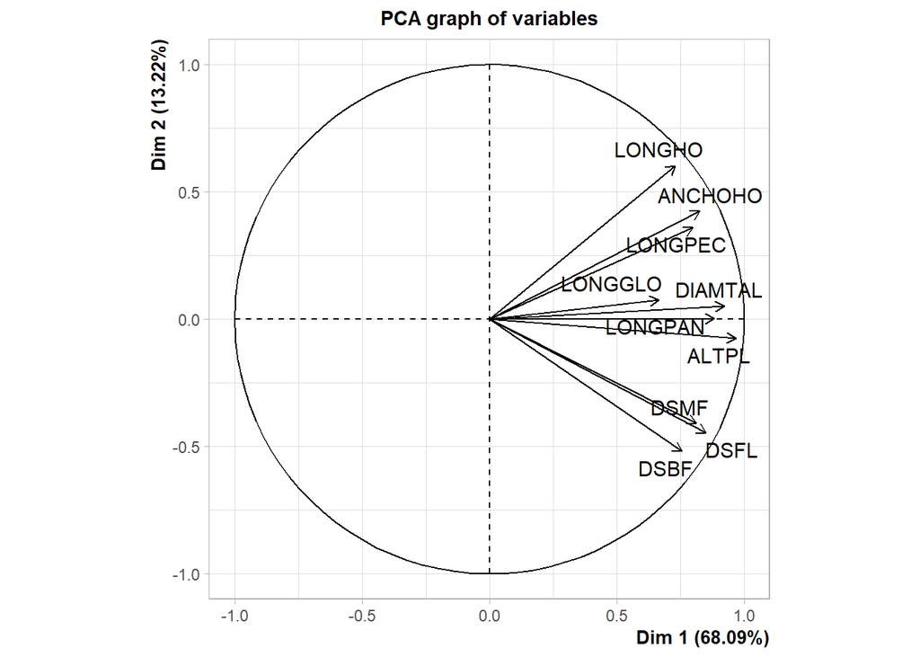

- En el gráfico, **cada vector representa una variable** del conjunto de datos original.
- La **dirección** y la **longitud de los vectores** indican la **importancia de cada variable y su correlación con las componentes principales**. Además, **el ángulo** entre los distintos vectores **refleja el grado de correlación entre las variables**: vectores con ángulos pequeños corresponden a variables altamente correlacionadas.
- En el gráfico se observa que las variables relacionadas con los días de desarrollo de la planta, están muy correlacionadas entre sí. Por otro lado, LONGPEC y ANCHOHO están muy correlacionadas entre sí. Por último, LONGGLO, ALTPL, LONGPAM y DIAMTAL están muy correlacionadas entre sí.
- Se puede ver que el vector con menor longitud es el de la variable LONGGLO, es decir, esta variable es la que menos contribuye a estas componentes.

### Biplot

A continuación, se presenta el mismo gráfico pero teniendo en cuenta la variable “Zona”, la cual nos indica en qué zona se desarrolla cada planta.

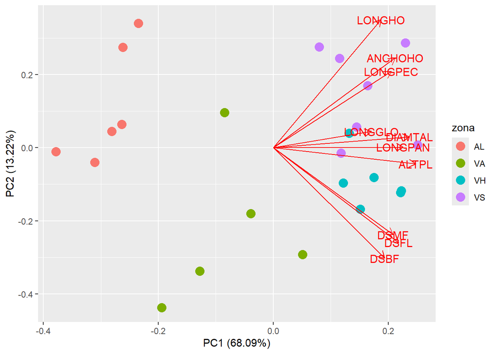

### Coordenadas de las variables en las Componentes Principales

|  | Dim.1 | Dim.2 | Dim.3 | Dim.4 | Dim.5 | Dim.6 | Dim.7 | Dim.8 | Dim.9 | Dim.10 |
| --- | --- | --- | --- | --- | --- | --- | --- | --- | --- | --- |
| DIAMTAL | 0.9218378 | 0.0513025 | -0.2660886 | -0.1945984 | -0.1226468 | -0.0860351 | -0.0379709 | -0.0130332 | 0.1217311 | 0.0060914 |
| ALTPL | 0.9668281 | -0.0761788 | -0.1113823 | -0.0416917 | -0.1127697 | 0.1058371 | -0.0651253 | -0.0935182 | -0.0442425 | -0.0802065 |
| LONGHO | 0.7297725 | 0.6021445 | 0.1466740 | 0.1268231 | 0.0369082 | -0.1856571 | 0.1722823 | 0.0141770 | 0.0042933 | -0.0390562 |
| ANCHOHO | 0.8268263 | 0.4235888 | 0.1115344 | 0.2410134 | -0.1657838 | -0.0907607 | -0.1654034 | 0.0049668 | -0.0367032 | 0.0441766 |
| LONGPEC | 0.7993316 | 0.3595091 | -0.2335920 | 0.1550618 | 0.2272308 | 0.3170426 | 0.0148144 | 0.0130180 | 0.0184509 | 0.0182639 |
| LONGPAN | 0.8815620 | 0.0027898 | -0.2620485 | -0.3601486 | -0.0776843 | -0.0088697 | 0.0906105 | 0.0503389 | -0.0787627 | 0.0374543 |
| LONGGLO | 0.6638879 | 0.0761330 | 0.6546657 | -0.3186660 | 0.1117839 | 0.0848225 | -0.0550560 | 0.0199945 | 0.0140812 | -0.0013176 |
| DSBF | 0.7547846 | -0.5196446 | 0.1711203 | 0.2306745 | -0.2148103 | 0.1162974 | 0.0670024 | 0.1148729 | 0.0183617 | -0.0092720 |
| DSFL | 0.8503928 | -0.4463454 | 0.1535134 | 0.1240425 | 0.0687219 | -0.0485773 | 0.0903795 | -0.1457321 | 0.0007433 | 0.0465360 |
| DSMF | 0.8116132 | -0.4089203 | -0.1514034 | 0.0657704 | 0.3062578 | -0.1982107 | -0.0906823 | 0.0704110 | -0.0140229 | -0.0189889 |

|  | Dim.1 | Dim.2 | Dim.3 | Dim.4 | Dim.5 | Dim.6 | Dim.7 | Dim.8 | Dim.9 | Dim.10 |
| --- | --- | --- | --- | --- | --- | --- | --- | --- | --- | --- |
| DIAMTAL | 0.8497849 | 0.0026319 | 0.0708031 | 0.0378685 | 0.0150422 | 0.0074020 | 0.0014418 | 0.0001699 | 0.0148185 | 0.0000371 |
| ALTPL | 0.9347566 | 0.0058032 | 0.0124060 | 0.0017382 | 0.0127170 | 0.0112015 | 0.0042413 | 0.0087457 | 0.0019574 | 0.0064331 |
| LONGHO | 0.5325679 | 0.3625780 | 0.0215133 | 0.0160841 | 0.0013622 | 0.0344686 | 0.0296812 | 0.0002010 | 0.0000184 | 0.0015254 |
| ANCHOHO | 0.6836417 | 0.1794275 | 0.0124399 | 0.0580874 | 0.0274843 | 0.0082375 | 0.0273583 | 0.0000247 | 0.0013471 | 0.0019516 |
| LONGPEC | 0.6389311 | 0.1292468 | 0.0545652 | 0.0240442 | 0.0516339 | 0.1005160 | 0.0002195 | 0.0001695 | 0.0003404 | 0.0003336 |
| LONGPAN | 0.7771516 | 0.0000078 | 0.0686694 | 0.1297070 | 0.0060348 | 0.0000787 | 0.0082103 | 0.0025340 | 0.0062036 | 0.0014028 |
| LONGGLO | 0.4407472 | 0.0057962 | 0.4285872 | 0.1015480 | 0.0124956 | 0.0071949 | 0.0030312 | 0.0003998 | 0.0001983 | 0.0000017 |
| DSBF | 0.5696998 | 0.2700305 | 0.0292822 | 0.0532107 | 0.0461435 | 0.0135251 | 0.0044893 | 0.0131958 | 0.0003372 | 0.0000860 |
| DSFL | 0.7231680 | 0.1992242 | 0.0235664 | 0.0153865 | 0.0047227 | 0.0023597 | 0.0081685 | 0.0212378 | 0.0000006 | 0.0021656 |
| DSMF | 0.6587159 | 0.1672158 | 0.0229230 | 0.0043257 | 0.0937938 | 0.0392875 | 0.0082233 | 0.0049577 | 0.0001966 | 0.0003606 |

En ambas tablas se puede visualizar que DIAMTAL, LONGPAN y ALTPL son las variables que más contribuyen a la primera componente principal. Esto también se puede visualizar en el gráfico Biplot, al observar que el ángulo entre los vectores de estas variables y la CP1 es muy pequeño.

Por otro lado, se observa que las variables que más contribuyen a la segunda componente principal son LONGHO y DSBF. De la misma manera, se puede visualizar en el gráfico Biplot que son los ángulos más pequeños entre las variables y la CP2.

### Contribución de las variables con las Componentes Principales

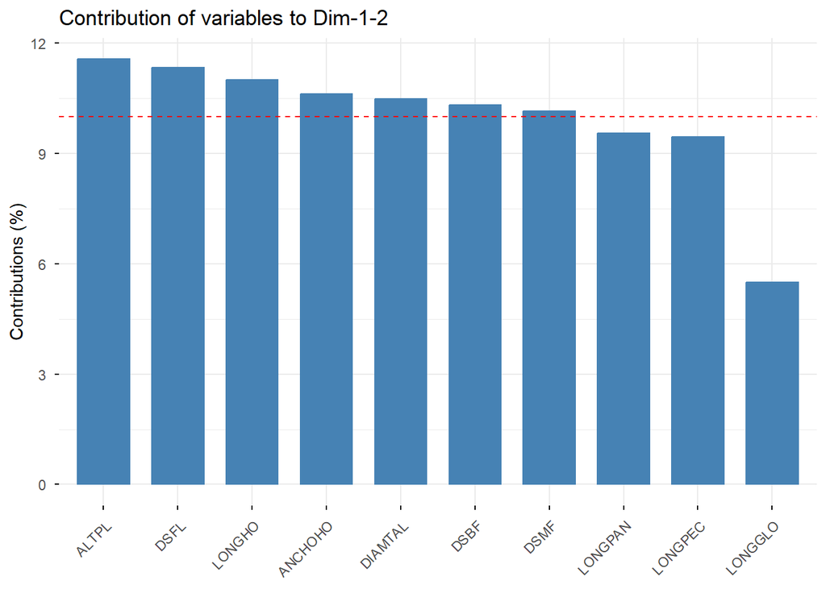

En este gráfico se vuelve a observar que la variable que menos contribuye a las dos primeras componentes principales es LONGGLO.

## **Conclusión**

La primera componente principal agrupa variables de longitud, diámetro y tamaño, las cuales están muy correlacionadas entre sí. Valores altos pueden definir tamaños de planta más grandes , mientras que valores pequeños, plantas más chicas.

La segunda componente principal puede ayudar a definir otras características de las plantas, como la velocidad de desarrollo con los distintos días desde la siembra.